# Introduction to Linear Regression

## Linear Regression

Simple and multiple linear regression

Presented by:  
Jingwen Zhong, Siyi Zhu, Jingxuan Feng, Coco Liu

## The advertising example

How are **sales** related to spending on **TV, radio, and newspaper advertising**?

- Data: advertising budgets and sales in **200 markets**.
- Response: sales, measured in **thousands of units**.
- Predictors: advertising budgets, measured in **thousands of dollars**.

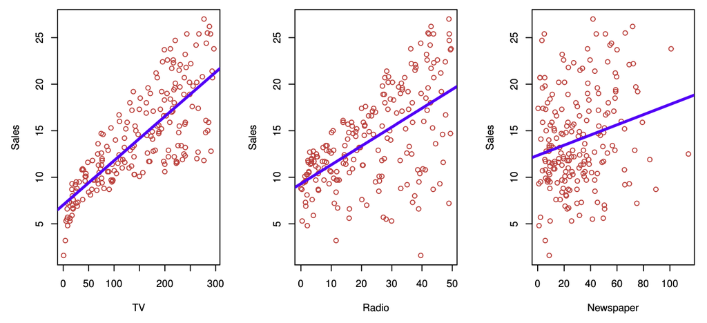

We want to understand the relationship and predict sales for a given advertising budget.

## Simple linear regression

$$Y=\beta_0+\beta_1X+\epsilon$$

| Term | Meaning |
| --- | --- |
| $\beta_0$ | Intercept: expected response when $X=0$ |
| $\beta_1$ | Slope: average change in $Y$ for a one-unit increase in $X$ |
| $\epsilon$ | Error: variation not captured by the linear relationship |

The true coefficients $\beta_0$ and $\beta_1$ are **unknown**, so we estimate them from the observed data.

$$\beta_0,\beta_1
\quad \longrightarrow \quad
\hat{\beta}_0,\hat{\beta}_1$$

A **hat** means “estimated from the sample”: $\hat{\beta}_0$ and $\hat{\beta}_1$ are estimates of the unknown population coefficients.

Using these estimates, we predict the response at $X=x$ with

$$\hat{y}=\hat{\beta}_0+\hat{\beta}_1x$$

## Fitting the line: least squares

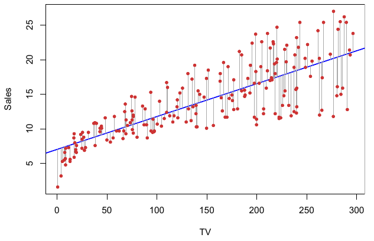

A **residual** is the difference between the observed and predicted response:
$$e_i=y_i-\hat y_i$$

Choose $\hat\beta_0$ and $\hat\beta_1$ to minimize the **residual sum of squares**:

$$\mathrm{RSS}
=
\sum_{i=1}^{n}(y_i-\hat y_i)^2
=
\sum_{i=1}^{n}(y_i-\hat\beta_0-\hat\beta_1x_i)^2$$

**Least squares fit:** choose $\hat\beta_0$ and $\hat\beta_1$ so the fitted line is as close as possible to the observed points, measured by squared vertical residuals.

## Interpreting the TV model

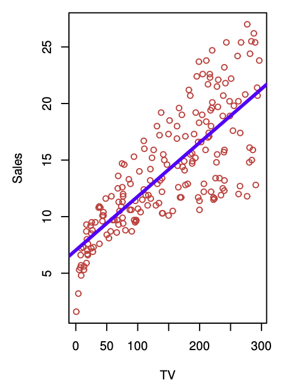

$$\widehat{\mathrm{sales}}
=
7.0325+0.0475\times\mathrm{TV}$$

- An additional **$1,000 in TV spending** is associated with an average increase of about **47.5 sales units**.
- At **$100,000 in TV spending**, predicted sales are about **11,783 units**.

Interpret the coefficient using the units of both the predictor and the response.

## How accurate are the coefficient estimates?

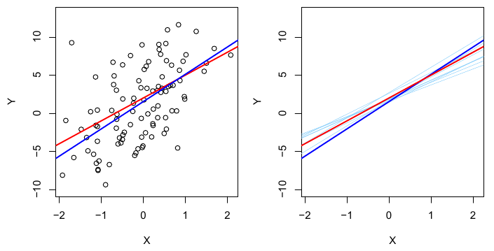

The **true regression line is fixed**, but different samples give different fitted lines.

So the estimated slope $\hat\beta_1$ varies from sample to sample.

A **standard error** measures this sampling variability.

**Smaller SE = more precise estimate.**

The slope is generally estimated more precisely with:

- **Less noise** around the line.
- **More observations** with a similar spread of $X$.
- **More spread in $X$**, with other factors unchanged.

## Confidence intervals for coefficients

An approximate **95% confidence interval** for the slope is:

$$\hat\beta_1\pm2\,\operatorname{SE}(\hat\beta_1)$$

For the TV regression:

$$0.042\leq\beta_1\leq0.053$$

This corresponds to about **42–53 additional sales units per $1,000** of TV spending.

The interval describes uncertainty about the slope, not the sales of one market.

## Is there a relationship?

Test whether the true slope is zero:

$$H_0:\beta_1=0
\qquad \text{versus} \qquad
H_a:\beta_1\ne0$$

Compare the estimated slope with its standard error:

$$t=\frac{\hat\beta_1}{\operatorname{SE}(\hat\beta_1)}$$

For TV: **$t=17.67$**, **$p<0.0001$**.

A very small p-value means that an estimated slope this far from zero would be very unlikely if $H_0$ were true.

We reject $H_0$. The data provide strong evidence of a relationship between TV advertising and sales.

## How well does the model fit?

$$\mathrm{RSE}=\sqrt{\frac{\mathrm{RSS}}{n-2}},
\qquad
R^2=1-\frac{\mathrm{RSS}}{\mathrm{TSS}}$$

where

$$\mathrm{TSS}=\sum_{i=1}^{n}(y_i-\bar y)^2,
\qquad
\mathrm{RSS}=\sum_{i=1}^{n}(y_i-\hat y_i)^2.$$

**TSS:** total variation in sales.  
**RSS:** variation left unexplained by the model.

- **RSE = 3.26:** about **3,260 sales units**.
- $\mathbf{R}^{\mathbf{2}}$ **= 0.612:** the model explains **61.2%** of the variation in sales.

**Takeaway:** RSE is in response units; $R^2$ is a proportion.

## Multiple linear regression

$$Y=\beta_0+\beta_1X_1+\cdots+\beta_pX_p+\epsilon.$$

Each coefficient measures the association between one predictor and the response, **holding all other predictors constant**.

For the advertising data,

$$\text{sales}
=
\beta_0
+\beta_1 \times \text{TV}
+\beta_2 \times \text{radio}
+\beta_3 \times \text{newspaper}
+\epsilon.
\tag{3.20}$$

| Intercept | TV | Radio | Newspaper |
| --- | --- | --- | --- |
| 2.939 | 0.046 | **0.189** | −0.001 |

### What does “holding the other predictors constant” mean?

To interpret the radio coefficient, compare two markets with the **same TV and newspaper budgets**, but with radio spending differing by $1,000.

So, **holding TV and newspaper spending constant**, an additional $1,000 spent on radio is associated with about **189 more units of sales on average**.

This is an association; it does not by itself establish cause and effect.

## Why does the newspaper coefficient change?

| Newspaper | Newspaper alone | With TV and radio |
| --- | --- | --- |
| Coefficient | 0.055 | −0.001 |
| p-value | 0.00115 | 0.8599 |

### What is happening?

Newspaper and radio budgets are positively correlated:

$$\mathrm{Cor}(\text{newspaper}, \text{radio}) = 0.3541$$

So markets that spend more on newspaper also tend to spend more on radio.

Once TV and radio are held fixed, the estimated newspaper effect is close to zero and is not statistically significant.

## Testing the multiple regression model

$$H_0:\beta_1=\beta_2=\cdots=\beta_p=0
\qquad
H_a:\text{at least one }\beta_j\neq 0$$

The overall F-statistic is

$$F=
\frac{(\mathrm{TSS}-\mathrm{RSS})/p}
{\mathrm{RSS}/(n-p-1)}$$

For the advertising data:

$$F \approx 570,\qquad p\text{-value}<0.0001$$

We reject $H_0$: there is very strong evidence that **at least one advertising medium is associated with sales**.

| Predictor | Coefficient | Std. Error | t-statistic | p-value |
| --- | --- | --- | --- | --- |
| TV | 0.046 | 0.0014 | 32.81 | < 0.0001 |
| Radio | 0.189 | 0.0086 | 21.89 | < 0.0001 |
| Newspaper | −0.001 | 0.0059 | −0.18 | 0.8599 |

- **F-test:** tests the predictors **jointly**.
- **individual t-test:** tests one predictor **while holding the others fixed**.

## Choosing useful predictors

**Variable selection** identifies a subset of predictors to include in the model.

With $p$ predictors, there are **$2^p$ possible subsets**. For $p = 30$, this means over **one billion models**.

| Method | Procedure |
| --- | --- |
| Forward selection | Start with an intercept only; add the predictor that gives the lowest RSS at each step. |
| Backward selection | Start with all predictors; remove the predictor with the largest $p$-value, then refit. |
| Mixed selection | Add predictors as in forward selection; remove included predictors if their $p$-values exceed a threshold. |

Each method continues until a **stopping rule** is met.

## Comparing the advertising models

| Predictors | R² | RSE |
| --- | --- | --- |
| TV | 0.612 | 3.26 |
| TV + radio | 0.89719 | 1.681 |
| TV + radio + newspaper | 0.89720 | 1.686 |

Adding radio gives a substantial improvement.

Adding newspaper changes R² very little and slightly increases RSE.

For multiple regression, RSE = $\sqrt{\frac{\mathrm{RSS}}{(n-p-1)}}$. RSE is in thousands of sales units.

## How accurate are the predictions?

Three sources of uncertainty:

- **Coefficient estimation:** the fitted coefficients depend on the sample.
- **Model bias:** a linear model may only approximate the true relationship.
- **Irreducible error:** individual responses vary even at the same budgets.

At TV = **$100,000** and radio = **$20,000**, predicted sales ≈ **11,256 units**.

| What are we predicting? | 95% interval, sales units |
| --- | --- |
| Average sales: confidence interval | 10,985–11,528 |
| One city’s sales: prediction interval | 7,930–14,580 |

The prediction interval also includes individual error, so it is wider. Neither interval automatically accounts for model bias.

## Interaction: TV and radio working together

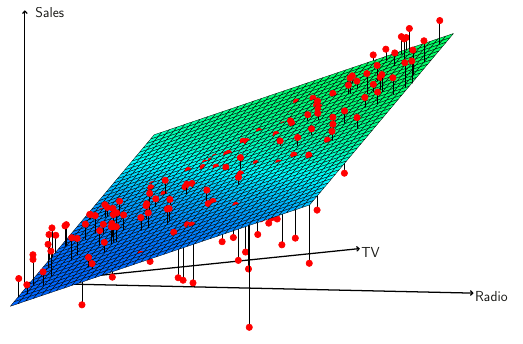

An **interaction** means the relationship between one predictor and sales depends on the other predictor.

When TV and radio budgets are similar, actual sales tend to be **higher than the model predicts**.

This suggests that TV and radio may work especially well **together**, beyond their separate contributions.

## Extension: can linear regression fit a curve?

Adding a squared predictor makes the model more flexible:
$$Y=\beta_0+\beta_1X+\beta_2X^2+\epsilon$$

- Treat **$X$ and $X^2$ as two predictors**; fit them using least squares.
- Still **linear in the coefficients**, even though the fitted relationship can curve.
- Example: increases in average sales could become smaller as TV spending grows.

**Discussion:** Would adding more powers of $X$ always improve predictions for new data?

## Main points

**Simple regression:** Uses one predictor to describe the response.

**Multiple regression:** Uses several predictors; interpret each slope while holding the others fixed.

**Fit:** Least squares minimizes the sum of squared residuals.

**Assess:** Standard errors, intervals, and tests describe uncertainty; RSE and R² describe fit.

**Predict:** A confidence interval concerns the average response; a prediction interval concerns an individual response.

**Interaction:** The relationship between one predictor and the response can depend on another predictor.

Reference: *An Introduction to Statistical Learning* — Gareth James et al.

## 10-minute lab: your turn

Open `linear_regression_workshop.qmd`.

Your tasks:

1. Fit `sales ~ TV`.
2. Interpret the TV slope and $R^2$.
3. Fit `sales ~ TV + radio + newspaper`.
4. Compare the newspaper coefficient and p-value across simple and multiple regression.
5. Produce a confidence interval and a prediction interval for a new market.

**Main question:** Why does newspaper look useful alone but not after accounting for TV and radio?